# Demographic predictors of birth counts in US counties from 2011-2020

In this notebook we will explore predictors of natality, defined here as birth count per county/year, for a subset of US counties between 2011 and 2020.

```python
import pandas as pd
import numpy as np
from prep import births, demog, pop, na, age_groups, rucc, adi
import statsmodels.api as sm
import matplotlib.pyplot as plt
import seaborn as sns
from statsmodels.nonparametric.smoothers_lowess import lowess
```

View some of the raw data:

```python
births.head()
```

|  | County | FIPS | Births | year |
| --- | --- | --- | --- | --- |
| 0 | Baldwin County, AL | 01003 | 2157.0 | 2011 |
| 1 | Calhoun County, AL | 01015 | 1418.0 | 2011 |
| 2 | Etowah County, AL | 01055 | 1173.0 | 2011 |
| 3 | Jefferson County, AL | 01073 | 8916.0 | 2011 |
| 4 | Lee County, AL | 01081 | 1536.0 | 2011 |

```python
pop.head()
```

|  | FIPS | Population |
| --- | --- | --- |
| 0 | 01001 | 56943 |
| 1 | 01003 | 209832 |
| 2 | 01005 | 26304 |
| 3 | 01007 | 22652 |
| 4 | 01009 | 58197 |

```python
adi.head()
```

```
FIPS5
01001    73.0
01003    53.5
01005    92.0
01007    84.0
01009    76.0
Name: ADI_NATRANK, dtype: float64
```

```python
rucc.head()
```

|  | FIPS | RUCC_2013 |
| --- | --- | --- |
| 0 | 01001 | 2.0 |
| 1 | 01003 | 3.0 |
| 2 | 01005 | 6.0 |
| 3 | 01007 | 1.0 |
| 4 | 01009 | 1.0 |

```python
demog.head()
```

| FIPS | W_N_M_0 | W_N_M_1 | W_N_M_2 | W_N_M_3 | W_N_M_4 | W_N_M_5 | W_N_M_6 | W_N_M_7 | W_N_M_8 | W_N_M_9 | ... | A_H_M_19 | N_H_M_18 | N_H_F_19 | A_H_M_16 | N_H_M_17 | N_H_M_19 | N_H_F_18 | A_H_F_18 | A_H_F_19 | B_H_M_19 |
| --- | --- | --- | --- | --- | --- | --- | --- | --- | --- | --- | --- | --- | --- | --- | --- | --- | --- | --- | --- | --- | --- |
| 01001 | 243.0 | 983.0 | 1409.0 | 1489.0 | 1498.0 | 1236.0 | 1290.0 | 1271.0 | 1330.0 | 1434.0 | ... | 0.0 | 0.0 | 0.0 | 0.0 | 0.0 | 0.0 | 0.0 | 0.0 | 0.0 | 0.0 |
| 01003 | 913.0 | 3696.0 | 4943.0 | 5483.0 | 5138.0 | 4317.0 | 4529.0 | 4656.0 | 5057.0 | 5273.0 | ... | 0.0 | 0.0 | 0.0 | 0.0 | 0.0 | 0.0 | 0.0 | 0.0 | 0.0 | 0.0 |
| 01005 | 41.0 | 201.0 | 273.0 | 278.0 | 313.0 | 360.0 | 418.0 | 386.0 | 409.0 | 454.0 | ... | 0.0 | 0.0 | 0.0 | 0.0 | 0.0 | 0.0 | 0.0 | 0.0 | 0.0 | 0.0 |
| 01007 | 108.0 | 355.0 | 510.0 | 576.0 | 539.0 | 471.0 | 562.0 | 544.0 | 563.0 | 613.0 | ... | 0.0 | 0.0 | 0.0 | 0.0 | 0.0 | 0.0 | 0.0 | 0.0 | 0.0 | 0.0 |
| 01009 | 269.0 | 1136.0 | 1527.0 | 1590.0 | 1674.0 | 1436.0 | 1441.0 | 1361.0 | 1528.0 | 1566.0 | ... | 0.0 | 0.0 | 0.0 | 0.0 | 0.0 | 0.0 | 0.0 | 0.0 | 0.0 | 0.0 |

5 rows × 320 columns

Create a dataframe for modeling. Merge the birth data with population and RUCC data.

```python
da = pd.merge(births, pop, on="FIPS", how="left")
da = pd.merge(da, rucc, on="FIPS", how="left")
da = pd.merge(da, adi, left_on="FIPS", right_on="FIPS5", how="left")
```

Population will be used as an offset below, so we log it here.

```python
da["logPop"] = np.log(da["Population"])
da["logADINatRank"] = np.log(1 + da["ADI_NATRANK"])
da = da.dropna()
```

It's not always essential to center quantitative variables, but it makes it easier to interpret their effects, especially when interactions are used.

```python
da["yearc"] = da["year"] - da["year"].mean()
da["logPopc"] = da["logPop"] - da["logPop"].mean()
da["RUCC_2013c"] = da["RUCC_2013"] - da["RUCC_2013"].mean()
da["logADINatRank"] = da["logADINatRank"] - da["logADINatRank"].mean()
da["logADINatRankZ"] = da["logADINatRank"] / da["logADINatRank"].std()
```

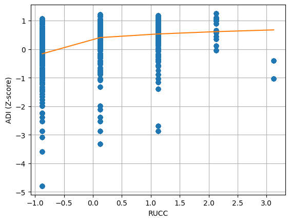

```python
px = da[["RUCC_2013c", "logADINatRankZ"]]
lm = lowess(px["logADINatRankZ"], px["RUCC_2013c"])
plt.plot(px["RUCC_2013c"], px["logADINatRankZ"], "o")
plt.xlabel("RUCC")
plt.ylabel("ADI (Z-score)")
plt.plot(lm[:, 0], lm[:, 1])
plt.grid(True)
```

## Scaling by population size and offsets

It is natural to expect a 1-1 scaling between total population size and the number of births. That is, all else equal we would expect two counties that differ by a factor of two in population size to differ by two in natality. To assess this, we can make a scatterplot of the birth count versus the population size in log-space. Under the expected 1-1 scaling, the slope of this line should be close to 1.

```python
da = da.sort_values(["FIPS", "year"])
da.head()
```

|  | County | FIPS | Births | year | Population | RUCC_2013 | ADI_NATRANK | logPop | logADINatRank | yearc | logPopc | RUCC_2013c | logADINatRankZ |
| --- | --- | --- | --- | --- | --- | --- | --- | --- | --- | --- | --- | --- | --- |
| 0 | Baldwin County, AL | 01003 | 2157.0 | 2011 | 209832 | 3.0 | 53.5 | 12.254062 | 0.152251 | -4.602384 | -0.332425 | 1.124052 | 0.265577 |
| 524 | Baldwin County, AL | 01003 | 2109.0 | 2012 | 209832 | 3.0 | 53.5 | 12.254062 | 0.152251 | -3.602384 | -0.332425 | 1.124052 | 0.265577 |
| 1048 | Baldwin County, AL | 01003 | 2160.0 | 2013 | 209832 | 3.0 | 53.5 | 12.254062 | 0.152251 | -2.602384 | -0.332425 | 1.124052 | 0.265577 |
| 1572 | Baldwin County, AL | 01003 | 2244.0 | 2014 | 209832 | 3.0 | 53.5 | 12.254062 | 0.152251 | -1.602384 | -0.332425 | 1.124052 | 0.265577 |
| 2150 | Baldwin County, AL | 01003 | 2344.0 | 2015 | 209832 | 3.0 | 53.5 | 12.254062 | 0.152251 | -0.602384 | -0.332425 | 1.124052 | 0.265577 |

```
1.031047058498305
```

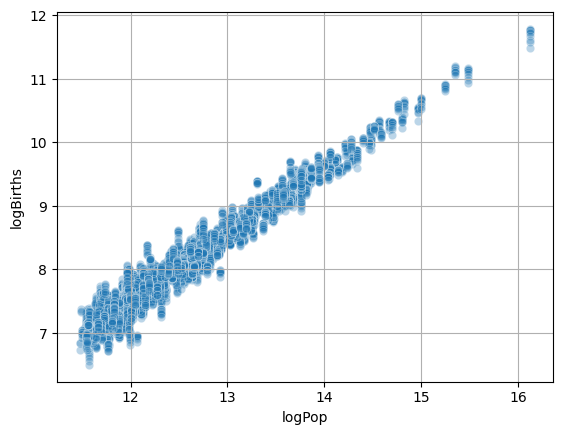

```python
da["logBirths"] = np.log(da["Births"])
sns.scatterplot(da, x="logPop", y="logBirths", alpha=0.3)
plt.grid(True)
b = np.cov(da["logPop"], da["logBirths"])[0, 1] / np.var(da["logPop"])
b
```

## Assessing the variance structure and mean/variance relationships

Since we have 10 years of data for each county, we can treat these as replicates to estimate the mean and variance within each county (over the 10 years covered by the dataset). This is one way for us to assess the mean/variance relationship.

```python
mv = births.groupby("FIPS")["Births"].agg([np.mean, np.var])
lmv = np.log(mv)
mv
```

| FIPS | mean | var |
| --- | --- | --- |
| 01003 | 2249.400000 | 6699.600000 |
| 01015 | 1335.600000 | 3090.711111 |
| 01055 | 1190.100000 | 804.100000 |
| 01069 | 1323.714286 | 751.904762 |
| 01073 | 8650.800000 | 100633.288889 |
| ... | ... | ... |
| 55117 | 1237.000000 | 3276.222222 |
| 55127 | 961.571429 | 6687.952381 |
| 55131 | 1308.200000 | 3390.400000 |
| 55133 | 3814.600000 | 11602.044444 |
| 55139 | 1840.500000 | 5808.277778 |

580 rows × 2 columns

Regress log variance on log mean

```python
mr = sm.OLS.from_formula("var ~ mean", lmv).fit()
print(mr.summary())
```

```
                            OLS Regression Results
==============================================================================
Dep. Variable:                    var   R-squared:                       0.779
Model:                            OLS   Adj. R-squared:                  0.779
Method:                 Least Squares   F-statistic:                     2042.
Date:                Mon, 17 Mar 2025   Prob (F-statistic):          7.38e-192
Time:                        08:59:34   Log-Likelihood:                -735.05
No. Observations:                 580   AIC:                             1474.
Df Residuals:                     578   BIC:                             1483.
Df Model:                           1
Covariance Type:            nonrobust
==============================================================================
                 coef    std err          t      P>|t|      [0.025      0.975]
------------------------------------------------------------------------------
Intercept     -5.4898      0.338    -16.231      0.000      -6.154      -4.826
mean           1.8755      0.042     45.192      0.000       1.794       1.957
==============================================================================
Omnibus:                        1.181   Durbin-Watson:                   1.536
Prob(Omnibus):                  0.554   Jarque-Bera (JB):                1.203
Skew:                           0.040   Prob(JB):                        0.548
Kurtosis:                       2.791   Cond. No.                         78.3
==============================================================================

Notes:
[1] Standard Errors assume that the covariance matrix of the errors is correctly specified.
```

Plot the log variance against the log mean. If variance = phi * mean, then log(variance) = log(phi) + log(mean), i.e. the slope is 1 and the intercept is log(phi). If variance = phi * mean^a then log(variance) = log(phi) + a * log(mean).

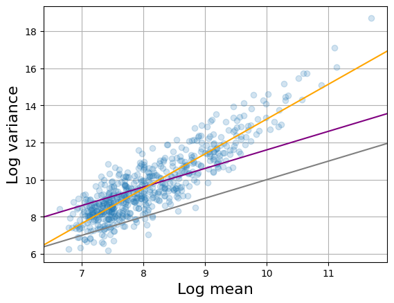

```python
plt.clf()
plt.grid(True)
plt.plot(lmv["mean"], lmv["var"], "o", alpha=0.2, rasterized=True)
plt.axline((8, 8), slope=1, color="grey")
plt.axline((lmv["mean"].mean(0), lmv["var"].mean(0)), slope=1, color="purple")
plt.axline((8, mr.params[0]+8*mr.params[1]), slope=mr.params[1], color="orange")
plt.xlabel("Log mean", size=16)
plt.ylabel("Log variance", size=16)
```

## Urbanicity and time trends as predictors of natality

Below we fit a GLM, which is not appropriate since we have repeated measures on counties. Due to the repeated measures, the uncertainty assessments (standard errors, p-values, confidence intervals, score tests) will be invalid, but the point estimates of the coefficients are still meaningful.

```python
fml = "Births ~ logPop + RUCC_2013 + logADINatRankZ"
m0 = sm.GLM.from_formula(fml, family=sm.families.Poisson(), data=da)
r0 = m0.fit() # Poisson
r0x = m0.fit(scale="X2") # Quasi-Poisson
r0x.summary()
```

Generalized Linear Model Regression Results

| Dep. Variable: | Births | No. Observations: | 5538 |
| --- | --- | --- | --- |
| Model: | GLM | Df Residuals: | 5534 |
| Model Family: | Poisson | Df Model: | 3 |
| Link Function: | Log | Scale: | 121.58 |
| Method: | IRLS | Log-Likelihood: | -2950.1 |
| Date: | Mon, 17 Mar 2025 | Deviance: | 6.6212e+05 |
| Time: | 08:59:34 | Pearson chi2: | 6.73e+05 |
| No. Iterations: | 7 | Pseudo R-squ. (CS): | 1.000 |
| Covariance Type: | nonrobust |  |  |

|  | coef | std err | z | P>\|z\| | [0.025 | 0.975] |
| --- | --- | --- | --- | --- | --- | --- |
| Intercept | -5.1080 | 0.035 | -146.426 | 0.000 | -5.176 | -5.040 |
| logPop | 1.0504 | 0.002 | 448.453 | 0.000 | 1.046 | 1.055 |
| RUCC_2013 | 0.0213 | 0.004 | 5.636 | 0.000 | 0.014 | 0.029 |
| logADINatRankZ | 0.0383 | 0.002 | 21.218 | 0.000 | 0.035 | 0.042 |

Using GEE accounts for the correlated data. After accounting for clustering by county, ADI remains significant but RUCC looses significance.

```python
m1 = sm.GEE.from_formula(fml, groups="FIPS", family=sm.families.Poisson(), data=da)
r1 = m1.fit() # Poisson and quasi-Poisson are the same for GEE
r1x = m1.fit(scale="X2")
r1x.summary()
```

GEE Regression Results

| Dep. Variable: | Births | No. Observations: | 5538 |
| --- | --- | --- | --- |
| Model: | GEE | No. clusters: | 572 |
| Method: | Generalized | Min. cluster size: | 3 |
|  | Estimating Equations | Max. cluster size: | 10 |
| Family: | Poisson | Mean cluster size: | 9.7 |
| Dependence structure: | Independence | Num. iterations: | 2 |
| Date: | Mon, 17 Mar 2025 | Scale: | 121.579 |
| Covariance type: | robust | Time: | 08:59:35 |

|  | coef | std err | z | P>\|z\| | [0.025 | 0.975] |
| --- | --- | --- | --- | --- | --- | --- |
| Intercept | -5.1080 | 0.160 | -32.022 | 0.000 | -5.421 | -4.795 |
| logPop | 1.0504 | 0.011 | 93.364 | 0.000 | 1.028 | 1.072 |
| RUCC_2013 | 0.0213 | 0.013 | 1.702 | 0.089 | -0.003 | 0.046 |
| logADINatRankZ | 0.0383 | 0.008 | 4.680 | 0.000 | 0.022 | 0.054 |

| Skew: | -4.2744 | Kurtosis: | 120.1045 |
| --- | --- | --- | --- |
| Centered skew: | -8.0432 | Centered kurtosis: | 389.5965 |

Use log population as an offset instead of a covariate

```python
m2 = sm.GEE.from_formula("Births ~ RUCC_2013 + logADINatRankZ", groups="FIPS", offset="logPop",
                         family=sm.families.Poisson(), data=da)
r2 = m2.fit(scale="X2")
r2.summary()
```

GEE Regression Results

| Dep. Variable: | Births | No. Observations: | 5538 |
| --- | --- | --- | --- |
| Model: | GEE | No. clusters: | 572 |
| Method: | Generalized | Min. cluster size: | 3 |
|  | Estimating Equations | Max. cluster size: | 10 |
| Family: | Poisson | Mean cluster size: | 9.7 |
| Dependence structure: | Independence | Num. iterations: | 2 |
| Date: | Mon, 17 Mar 2025 | Scale: | 130.954 |
| Covariance type: | robust | Time: | 08:59:35 |

|  | coef | std err | z | P>\|z\| | [0.025 | 0.975] |
| --- | --- | --- | --- | --- | --- | --- |
| Intercept | -4.3680 | 0.021 | -205.463 | 0.000 | -4.410 | -4.326 |
| RUCC_2013 | -0.0224 | 0.011 | -2.011 | 0.044 | -0.044 | -0.001 |
| logADINatRankZ | 0.0270 | 0.008 | 3.385 | 0.001 | 0.011 | 0.043 |

| Skew: | 2.4803 | Kurtosis: | 42.3204 |
| --- | --- | --- | --- |
| Centered skew: | -8.0432 | Centered kurtosis: | 389.5965 |

Below we construct a diagnostic plot for the variance structure that does not require there to be replicates (in general there will be no replicates, and even here it is unclear whether we can treat the 10 years of data within each county as replicates). If the variance structure is correctly specified, then the absolute Pearson residuals should have constant conditional mean with respect to the fitted values.

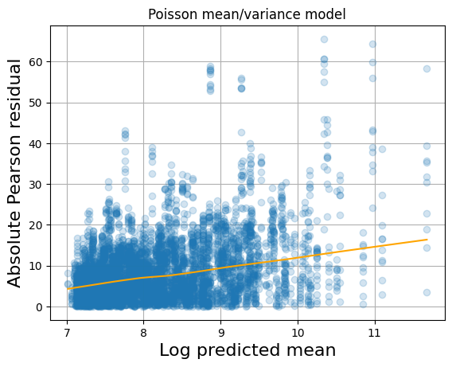

```python
plt.clf()
plt.grid(True)
lfv = np.log(r2.fittedvalues).values
apr = np.abs(r2.resid_pearson)
ii = np.argsort(lfv)
lfv = lfv[ii]
apr = apr[ii]
ff = sm.nonparametric.lowess(apr, lfv)
plt.plot(lfv, apr, "o", alpha=0.2, rasterized=True)
plt.plot(ff[:, 0], ff[:, 1], "-", color="orange")
plt.title("Poisson mean/variance model")
plt.xlabel("Log predicted mean", size=16)
plt.ylabel("Absolute Pearson residual", size=16)
```

The Poisson variance model did not fit well based on the diagnostic plot above, so we next consider a Gamma family to better match the mean/variance relationship.

```python
m3 = sm.GEE.from_formula("Births ~ RUCC_2013", groups="FIPS", offset="logPop",
                         family=sm.families.Gamma(link=sm.families.links.log()), data=da)
r3 = m3.fit(scale="X2")
r3.summary()
```

GEE Regression Results

| Dep. Variable: | Births | No. Observations: | 5538 |
| --- | --- | --- | --- |
| Model: | GEE | No. clusters: | 572 |
| Method: | Generalized | Min. cluster size: | 3 |
|  | Estimating Equations | Max. cluster size: | 10 |
| Family: | Gamma | Mean cluster size: | 9.7 |
| Dependence structure: | Independence | Num. iterations: | 2 |
| Date: | Mon, 17 Mar 2025 | Scale: | 0.032 |
| Covariance type: | robust | Time: | 08:59:37 |

|  | coef | std err | z | P>\|z\| | [0.025 | 0.975] |
| --- | --- | --- | --- | --- | --- | --- |
| Intercept | -4.4496 | 0.015 | -289.565 | 0.000 | -4.480 | -4.419 |
| RUCC_2013 | 0.0059 | 0.008 | 0.731 | 0.465 | -0.010 | 0.022 |

| Skew: | 3.3220 | Kurtosis: | 46.3145 |
| --- | --- | --- | --- |
| Centered skew: | -8.0432 | Centered kurtosis: | 389.5965 |

Diagnostic plot for mean/variance relationship with gamma model.

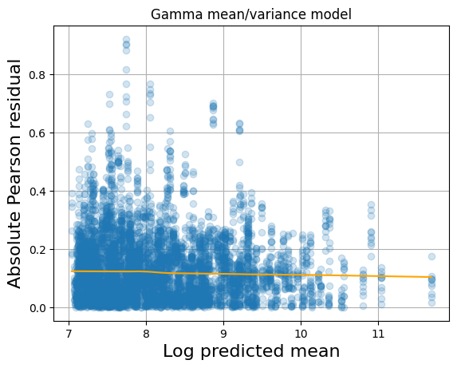

```python
plt.clf()
plt.grid(True)
lfv = np.log(r3.fittedvalues).values
apr = np.abs(r3.resid_pearson)
ii = np.argsort(lfv)
lfv = lfv[ii]
apr = apr[ii]
ff = sm.nonparametric.lowess(apr, lfv)
plt.plot(lfv, apr, "o", alpha=0.2, rasterized=True)
plt.plot(ff[:, 0], ff[:, 1], "-", color="orange")
plt.title("Gamma mean/variance model")
plt.xlabel("Log predicted mean", size=16)
plt.ylabel("Absolute Pearson residual", size=16)
```

Now we proceed to fit and interpret some regression models. Here we use exchangeable correlation structure in the GEE. Since RUCC and ADI are constant within groups, the parameter estimates and standard errors are the same as with the independence model. The first model only considers the roles of urbanicity (RUCC) and deprivation (ADI).

```python
m4 = sm.GEE.from_formula("Births ~ RUCC_2013 + logADINatRankZ", groups="FIPS", offset="logPop",
                         cov_struct=sm.cov_struct.Exchangeable(),
                         family=sm.families.Gamma(link=sm.families.links.log()), data=da)
r4 = m4.fit(scale="X2")
r4.summary()
```

GEE Regression Results

| Dep. Variable: | Births | No. Observations: | 5538 |
| --- | --- | --- | --- |
| Model: | GEE | No. clusters: | 572 |
| Method: | Generalized | Min. cluster size: | 3 |
|  | Estimating Equations | Max. cluster size: | 10 |
| Family: | Gamma | Mean cluster size: | 9.7 |
| Dependence structure: | Exchangeable | Num. iterations: | 6 |
| Date: | Mon, 17 Mar 2025 | Scale: | 0.031 |
| Covariance type: | robust | Time: | 08:59:39 |

|  | coef | std err | z | P>\|z\| | [0.025 | 0.975] |
| --- | --- | --- | --- | --- | --- | --- |
| Intercept | -4.4227 | 0.016 | -280.856 | 0.000 | -4.454 | -4.392 |
| RUCC_2013 | -0.0083 | 0.008 | -0.984 | 0.325 | -0.025 | 0.008 |
| logADINatRankZ | 0.0344 | 0.007 | 4.614 | 0.000 | 0.020 | 0.049 |

| Skew: | 5.0009 | Kurtosis: | 48.8183 |
| --- | --- | --- | --- |
| Centered skew: | -8.0432 | Centered kurtosis: | 389.5965 |

Now we consider the role of urbanicity as well as the potential for a linear time trend.

```python
m5 = sm.GEE.from_formula("Births ~ RUCC_2013 + logADINatRankZ + year", groups="FIPS", offset="logPop",
                         cov_struct=sm.cov_struct.Exchangeable(),
                         family=sm.families.Gamma(link=sm.families.links.log()), data=da)
r5 = m5.fit(scale="X2")
r5.summary()
```

GEE Regression Results

| Dep. Variable: | Births | No. Observations: | 5538 |
| --- | --- | --- | --- |
| Model: | GEE | No. clusters: | 572 |
| Method: | Generalized | Min. cluster size: | 3 |
|  | Estimating Equations | Max. cluster size: | 10 |
| Family: | Gamma | Mean cluster size: | 9.7 |
| Dependence structure: | Exchangeable | Num. iterations: | 7 |
| Date: | Mon, 17 Mar 2025 | Scale: | 0.031 |
| Covariance type: | robust | Time: | 08:59:40 |

|  | coef | std err | z | P>\|z\| | [0.025 | 0.975] |
| --- | --- | --- | --- | --- | --- | --- |
| Intercept | 11.0574 | 0.927 | 11.931 | 0.000 | 9.241 | 12.874 |
| RUCC_2013 | -0.0083 | 0.008 | -0.985 | 0.325 | -0.025 | 0.008 |
| logADINatRankZ | 0.0345 | 0.007 | 4.647 | 0.000 | 0.020 | 0.049 |
| year | -0.0077 | 0.000 | -16.729 | 0.000 | -0.009 | -0.007 |

| Skew: | 4.8764 | Kurtosis: | 42.6261 |
| --- | --- | --- | --- |
| Centered skew: | -8.8783 | Centered kurtosis: | 410.0012 |

Now we consider the possibility that the linear time trend is different based on the level of deprivation.

```python
m6 = sm.GEE.from_formula("Births ~ (logADINatRankZ + RUCC_2013c) * yearc", groups="FIPS", offset="logPop",
                         cov_struct=sm.cov_struct.Exchangeable(),
                         family=sm.families.Gamma(link=sm.families.links.log()), data=da)
r6 = m6.fit(scale="X2")
r6.summary()
```

GEE Regression Results

| Dep. Variable: | Births | No. Observations: | 5538 |
| --- | --- | --- | --- |
| Model: | GEE | No. clusters: | 572 |
| Method: | Generalized | Min. cluster size: | 3 |
|  | Estimating Equations | Max. cluster size: | 10 |
| Family: | Gamma | Mean cluster size: | 9.7 |
| Dependence structure: | Exchangeable | Num. iterations: | 8 |
| Date: | Mon, 17 Mar 2025 | Scale: | 0.031 |
| Covariance type: | robust | Time: | 08:59:41 |

|  | coef | std err | z | P>\|z\| | [0.025 | 0.975] |
| --- | --- | --- | --- | --- | --- | --- |
| Intercept | -4.4382 | 0.007 | -621.042 | 0.000 | -4.452 | -4.424 |
| logADINatRankZ | 0.0346 | 0.007 | 4.653 | 0.000 | 0.020 | 0.049 |
| RUCC_2013c | -0.0081 | 0.008 | -0.959 | 0.338 | -0.025 | 0.008 |
| yearc | -0.0077 | 0.000 | -17.143 | 0.000 | -0.009 | -0.007 |
| logADINatRankZ:yearc | 0.0011 | 0.000 | 2.182 | 0.029 | 0.000 | 0.002 |
| RUCC_2013c:yearc | -0.0032 | 0.001 | -6.010 | 0.000 | -0.004 | -0.002 |

| Skew: | 4.8786 | Kurtosis: | 42.7490 |
| --- | --- | --- | --- |
| Centered skew: | -8.8106 | Centered kurtosis: | 404.3912 |

Score tests comparing pairs of nested models:

```python
print(r5.model.compare_score_test(r4))
print(r6.model.compare_score_test(r5))
```

```
{'statistic': 177.05951675359339, 'df': 1, 'p-value': 0.0}
{'statistic': 29.776334628193418, 'df': 2, 'p-value': 3.420984369117974e-07}
```

## Principal Components Regression

We begin by double centering the demographic data.

```python
demogx = np.asarray(demog)
demogx = np.log(1 + demogx)
demogx -= demogx.mean()
demogx -= demogx.mean(0)
demogx -= demogx.mean(1)[:, None]
demog
```

| FIPS | W_N_M_0 | W_N_M_1 | W_N_M_2 | W_N_M_3 | W_N_M_4 | W_N_M_5 | W_N_M_6 | W_N_M_7 | W_N_M_8 | W_N_M_9 | ... | A_H_M_19 | N_H_M_18 | N_H_F_19 | A_H_M_16 | N_H_M_17 | N_H_M_19 | N_H_F_18 | A_H_F_18 | A_H_F_19 | B_H_M_19 |
| --- | --- | --- | --- | --- | --- | --- | --- | --- | --- | --- | --- | --- | --- | --- | --- | --- | --- | --- | --- | --- | --- |
| 01001 | 243.0 | 983.0 | 1409.0 | 1489.0 | 1498.0 | 1236.0 | 1290.0 | 1271.0 | 1330.0 | 1434.0 | ... | 0.0 | 0.0 | 0.0 | 0.0 | 0.0 | 0.0 | 0.0 | 0.0 | 0.0 | 0.0 |
| 01003 | 913.0 | 3696.0 | 4943.0 | 5483.0 | 5138.0 | 4317.0 | 4529.0 | 4656.0 | 5057.0 | 5273.0 | ... | 0.0 | 0.0 | 0.0 | 0.0 | 0.0 | 0.0 | 0.0 | 0.0 | 0.0 | 0.0 |
| 01005 | 41.0 | 201.0 | 273.0 | 278.0 | 313.0 | 360.0 | 418.0 | 386.0 | 409.0 | 454.0 | ... | 0.0 | 0.0 | 0.0 | 0.0 | 0.0 | 0.0 | 0.0 | 0.0 | 0.0 | 0.0 |
| 01007 | 108.0 | 355.0 | 510.0 | 576.0 | 539.0 | 471.0 | 562.0 | 544.0 | 563.0 | 613.0 | ... | 0.0 | 0.0 | 0.0 | 0.0 | 0.0 | 0.0 | 0.0 | 0.0 | 0.0 | 0.0 |
| 01009 | 269.0 | 1136.0 | 1527.0 | 1590.0 | 1674.0 | 1436.0 | 1441.0 | 1361.0 | 1528.0 | 1566.0 | ... | 0.0 | 0.0 | 0.0 | 0.0 | 0.0 | 0.0 | 0.0 | 0.0 | 0.0 | 0.0 |
| ... | ... | ... | ... | ... | ... | ... | ... | ... | ... | ... | ... | ... | ... | ... | ... | ... | ... | ... | ... | ... | ... |
| 56037 | 235.0 | 971.0 | 1305.0 | 1303.0 | 1184.0 | 1035.0 | 1248.0 | 1422.0 | 1408.0 | 1142.0 | ... | 0.0 | 0.0 | 0.0 | 0.0 | 0.0 | 0.0 | 1.0 | 0.0 | 0.0 | 0.0 |
| 56039 | 92.0 | 359.0 | 472.0 | 440.0 | 364.0 | 379.0 | 926.0 | 927.0 | 847.0 | 796.0 | ... | 0.0 | 0.0 | 1.0 | 0.0 | 0.0 | 0.0 | 0.0 | 0.0 | 0.0 | 0.0 |
| 56041 | 136.0 | 559.0 | 796.0 | 797.0 | 701.0 | 465.0 | 488.0 | 620.0 | 634.0 | 578.0 | ... | 0.0 | 0.0 | 0.0 | 1.0 | 0.0 | 0.0 | 0.0 | 0.0 | 0.0 | 0.0 |
| 56043 | 40.0 | 164.0 | 191.0 | 237.0 | 233.0 | 131.0 | 156.0 | 171.0 | 232.0 | 194.0 | ... | 0.0 | 1.0 | 0.0 | 0.0 | 0.0 | 0.0 | 0.0 | 0.0 | 0.0 | 0.0 |
| 56045 | 36.0 | 161.0 | 191.0 | 230.0 | 186.0 | 213.0 | 197.0 | 245.0 | 249.0 | 199.0 | ... | 0.0 | 0.0 | 0.0 | 0.0 | 1.0 | 0.0 | 0.0 | 0.0 | 0.0 | 0.0 |

3142 rows × 320 columns

Get factors (principal components) from the demographic data.

```python
u, s, vt = np.linalg.svd(demogx, 0)
v = vt.T
```

Convert the coefficients back to the original coordinates

```python
def convert_coef(c, npc):
    return np.dot(v[:, 0:npc], c/s[0:npc])
```

Put the demographic factors into a dataframe

```python
m = {("pc%02d" % k) : u[:, k] for k in range(100)}
m["FIPS"] = demog.index
demog_f = pd.DataFrame(m)
```

Merge demographic information into the births data

```python
da = pd.merge(da, demog_f, on="FIPS", how="left")
```

Include this number of factors in subsequent models

```python
npc = 10
```

A GLM, not appropriate since we have repeated measures on counties

```python
fml = "Births ~ (logPopc + RUCC_2013c) * yearc + " + " + ".join(["pc%02d" % j for j in range(npc)])
m7 = sm.GLM.from_formula(fml, family=sm.families.Poisson(), data=da)
r7 = m7.fit(scale="X2")
r7.summary()
```

Generalized Linear Model Regression Results

| Dep. Variable: | Births | No. Observations: | 5538 |
| --- | --- | --- | --- |
| Model: | GLM | Df Residuals: | 5522 |
| Model Family: | Poisson | Df Model: | 15 |
| Link Function: | Log | Scale: | 56.475 |
| Method: | IRLS | Log-Likelihood: | -3204.3 |
| Date: | Mon, 17 Mar 2025 | Deviance: | 3.0671e+05 |
| Time: | 08:59:42 | Pearson chi2: | 3.12e+05 |
| No. Iterations: | 7 | Pseudo R-squ. (CS): | 1.000 |
| Covariance Type: | nonrobust |  |  |

|  | coef | std err | z | P>\|z\| | [0.025 | 0.975] |
| --- | --- | --- | --- | --- | --- | --- |
| Intercept | 8.0737 | 0.008 | 1068.085 | 0.000 | 8.059 | 8.089 |
| logPopc | 1.0220 | 0.002 | 420.878 | 0.000 | 1.017 | 1.027 |
| RUCC_2013c | 0.0148 | 0.003 | 5.095 | 0.000 | 0.009 | 0.021 |
| yearc | -0.0066 | 0.001 | -10.155 | 0.000 | -0.008 | -0.005 |
| logPopc:yearc | -0.0051 | 0.001 | -9.429 | 0.000 | -0.006 | -0.004 |
| RUCC_2013c:yearc | -0.0056 | 0.001 | -6.274 | 0.000 | -0.007 | -0.004 |
| pc00 | -2.6240 | 0.215 | -12.185 | 0.000 | -3.046 | -2.202 |
| pc01 | -3.0352 | 0.187 | -16.198 | 0.000 | -3.403 | -2.668 |
| pc02 | 2.8670 | 0.091 | 31.580 | 0.000 | 2.689 | 3.045 |
| pc03 | 4.1588 | 0.127 | 32.825 | 0.000 | 3.910 | 4.407 |
| pc04 | 0.5087 | 0.091 | 5.605 | 0.000 | 0.331 | 0.687 |
| pc05 | -3.0466 | 0.083 | -36.600 | 0.000 | -3.210 | -2.883 |
| pc06 | -1.8030 | 0.131 | -13.728 | 0.000 | -2.060 | -1.546 |
| pc07 | -0.2797 | 0.135 | -2.068 | 0.039 | -0.545 | -0.015 |
| pc08 | 3.6057 | 0.172 | 21.022 | 0.000 | 3.270 | 3.942 |
| pc09 | -0.9029 | 0.078 | -11.527 | 0.000 | -1.056 | -0.749 |

GEE accounts for the correlated data

```python
m8 = sm.GEE.from_formula(fml, groups="FIPS",
         family=sm.families.Gamma(link=sm.families.links.log()), data=da)
r8 = m8.fit(scale="X2")
r8.summary()
```

GEE Regression Results

| Dep. Variable: | Births | No. Observations: | 5538 |
| --- | --- | --- | --- |
| Model: | GEE | No. clusters: | 572 |
| Method: | Generalized | Min. cluster size: | 3 |
|  | Estimating Equations | Max. cluster size: | 10 |
| Family: | Gamma | Mean cluster size: | 9.7 |
| Dependence structure: | Independence | Num. iterations: | 2 |
| Date: | Mon, 17 Mar 2025 | Scale: | 0.014 |
| Covariance type: | robust | Time: | 08:59:42 |

|  | coef | std err | z | P>\|z\| | [0.025 | 0.975] |
| --- | --- | --- | --- | --- | --- | --- |
| Intercept | 8.1690 | 0.027 | 300.995 | 0.000 | 8.116 | 8.222 |
| logPopc | 1.0615 | 0.013 | 81.805 | 0.000 | 1.036 | 1.087 |
| RUCC_2013c | 0.0128 | 0.007 | 1.896 | 0.058 | -0.000 | 0.026 |
| yearc | -0.0075 | 0.000 | -15.204 | 0.000 | -0.008 | -0.007 |
| logPopc:yearc | -0.0021 | 0.001 | -2.797 | 0.005 | -0.004 | -0.001 |
| RUCC_2013c:yearc | -0.0036 | 0.001 | -4.919 | 0.000 | -0.005 | -0.002 |
| pc00 | -0.8840 | 0.784 | -1.128 | 0.259 | -2.420 | 0.652 |
| pc01 | -0.6622 | 0.697 | -0.950 | 0.342 | -2.029 | 0.705 |
| pc02 | 3.9320 | 0.324 | 12.152 | 0.000 | 3.298 | 4.566 |
| pc03 | 3.6507 | 0.427 | 8.545 | 0.000 | 2.813 | 4.488 |
| pc04 | 1.3024 | 0.317 | 4.104 | 0.000 | 0.680 | 1.924 |
| pc05 | -3.0295 | 0.303 | -9.983 | 0.000 | -3.624 | -2.435 |
| pc06 | -2.6372 | 0.392 | -6.725 | 0.000 | -3.406 | -1.869 |
| pc07 | -0.5523 | 0.383 | -1.442 | 0.149 | -1.303 | 0.199 |
| pc08 | 3.5002 | 0.489 | 7.157 | 0.000 | 2.542 | 4.459 |
| pc09 | -1.7524 | 0.258 | -6.785 | 0.000 | -2.259 | -1.246 |

| Skew: | -12.7707 | Kurtosis: | 283.4610 |
| --- | --- | --- | --- |
| Centered skew: | -7.6129 | Centered kurtosis: | 309.3639 |

Use log population as an offset instead of a covariate

```python
fml = "Births ~ " + " + ".join(["pc%02d" % j for j in range(npc)])
m9 = sm.GEE.from_formula(fml, groups="FIPS", offset="logPop",
         family=sm.families.Gamma(link=sm.families.links.log()), data=da)
r9 = m9.fit(scale="X2")
r9.summary()
```

GEE Regression Results

| Dep. Variable: | Births | No. Observations: | 5538 |
| --- | --- | --- | --- |
| Model: | GEE | No. clusters: | 572 |
| Method: | Generalized | Min. cluster size: | 3 |
|  | Estimating Equations | Max. cluster size: | 10 |
| Family: | Gamma | Mean cluster size: | 9.7 |
| Dependence structure: | Independence | Num. iterations: | 2 |
| Date: | Mon, 17 Mar 2025 | Scale: | 0.015 |
| Covariance type: | robust | Time: | 08:59:42 |

|  | coef | std err | z | P>\|z\| | [0.025 | 0.975] |
| --- | --- | --- | --- | --- | --- | --- |
| Intercept | -4.5049 | 0.019 | -242.496 | 0.000 | -4.541 | -4.468 |
| pc00 | -2.7446 | 0.597 | -4.595 | 0.000 | -3.915 | -1.574 |
| pc01 | -2.4608 | 0.618 | -3.984 | 0.000 | -3.672 | -1.250 |
| pc02 | 3.6446 | 0.324 | 11.253 | 0.000 | 3.010 | 4.279 |
| pc03 | 4.5605 | 0.393 | 11.607 | 0.000 | 3.790 | 5.331 |
| pc04 | 0.6506 | 0.282 | 2.309 | 0.021 | 0.098 | 1.203 |
| pc05 | -2.6713 | 0.299 | -8.941 | 0.000 | -3.257 | -2.086 |
| pc06 | -2.2490 | 0.387 | -5.812 | 0.000 | -3.007 | -1.491 |
| pc07 | -0.5429 | 0.389 | -1.395 | 0.163 | -1.306 | 0.220 |
| pc08 | 2.8563 | 0.464 | 6.162 | 0.000 | 1.948 | 3.765 |
| pc09 | -1.3924 | 0.252 | -5.533 | 0.000 | -1.886 | -0.899 |

| Skew: | -1.4627 | Kurtosis: | 128.4478 |
| --- | --- | --- | --- |
| Centered skew: | -8.0432 | Centered kurtosis: | 389.5965 |

Restructure the coefficients so that the age bands are in the columns.

```python
def restructure(c):
    ii = pd.MultiIndex.from_tuples(na)
    c = pd.Series(c, index=ii)
    c = c.unstack()
    return c
```

This function fits a Gamma GLM to the data using 'npc' principal components as explanatory variables (using GEE to account for non-independence), then converts the coefficients back to the original variables.

```python
def fitmodel(npc):
    # A GEE using log population as an offset
    fml = "Births ~ 1" if npc == 0 else "Births ~ RUCC_2013c*yearc + " + " + ".join(["pc%02d" % j for j in range(npc)])
    m = sm.GEE.from_formula(fml, groups="FIPS", family=sm.families.Gamma(link=sm.families.links.log()),
                            offset=da["logPop"], data=da)
    r = m.fit(scale="X2")

    # Convert the coefficients back to the original coordinates
    c = convert_coef(r.params[4:], npc)

    # Restructure the coefficients so that the age bands are
    # in the columns.
    c = restructure(c)

    return c, m, r
```

Plot styling information

```python
colors = {"A": "purple", "B": "orange", "N": "lime", "W": "red"}
lt = {"F": "-", "M": ":"}
sym = {"H": "s", "N": "o"}
ages = range(0, 20)
```

Fit models with these numbers of PCs.

```python
pcs = [0, 5, 10, 20, 30, 40, 50, 60, 70, 80, 90, 100]
```

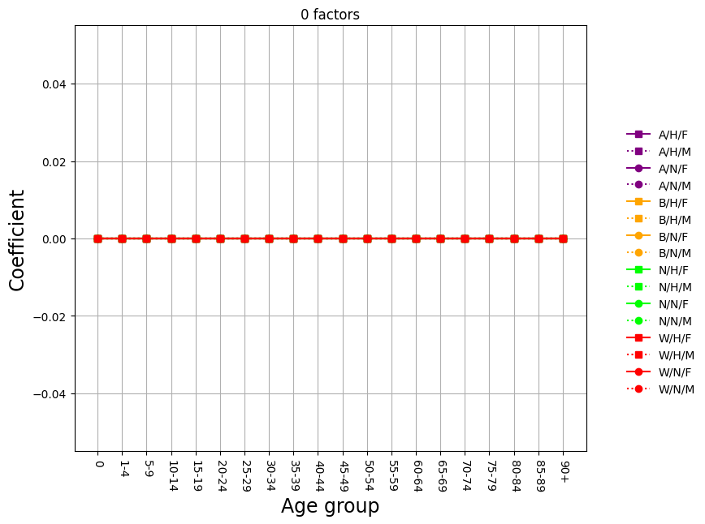

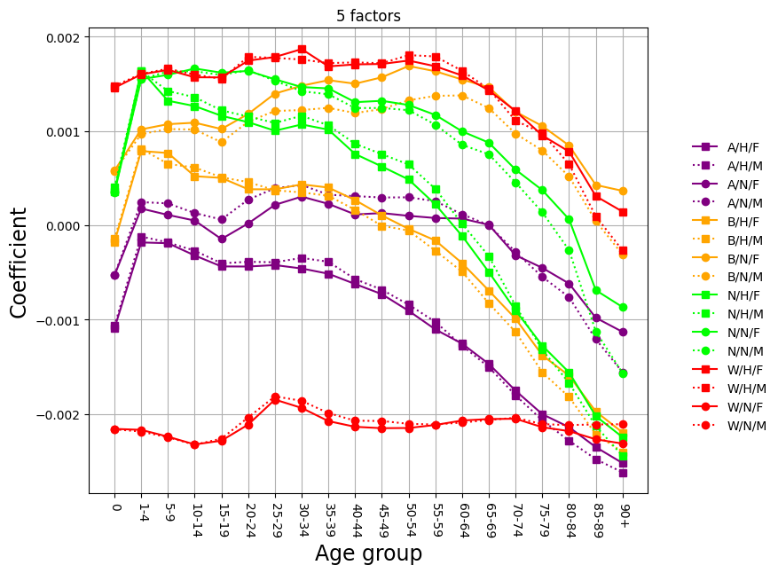

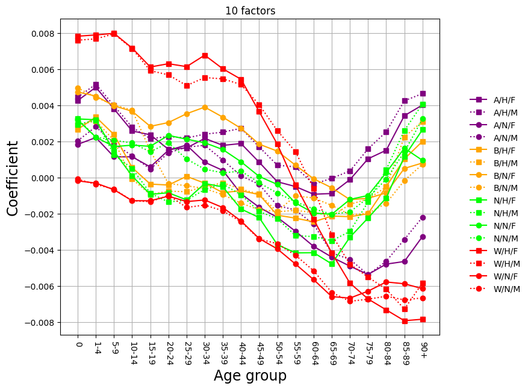

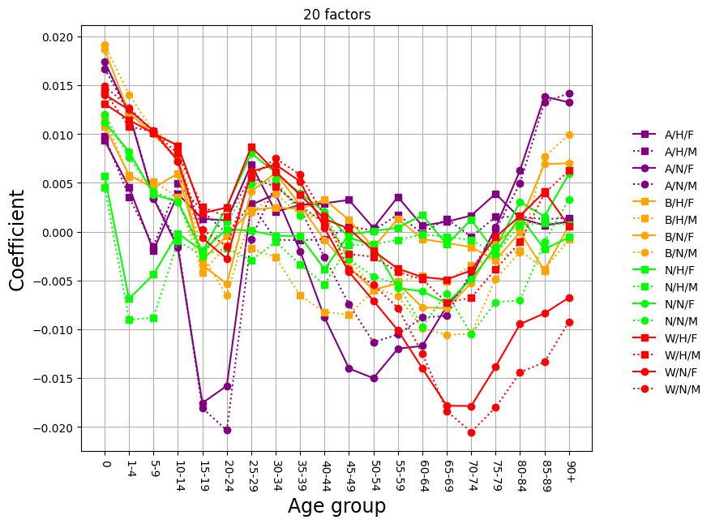

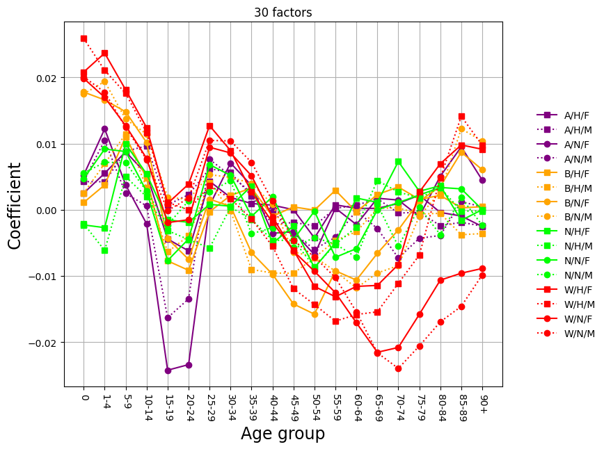

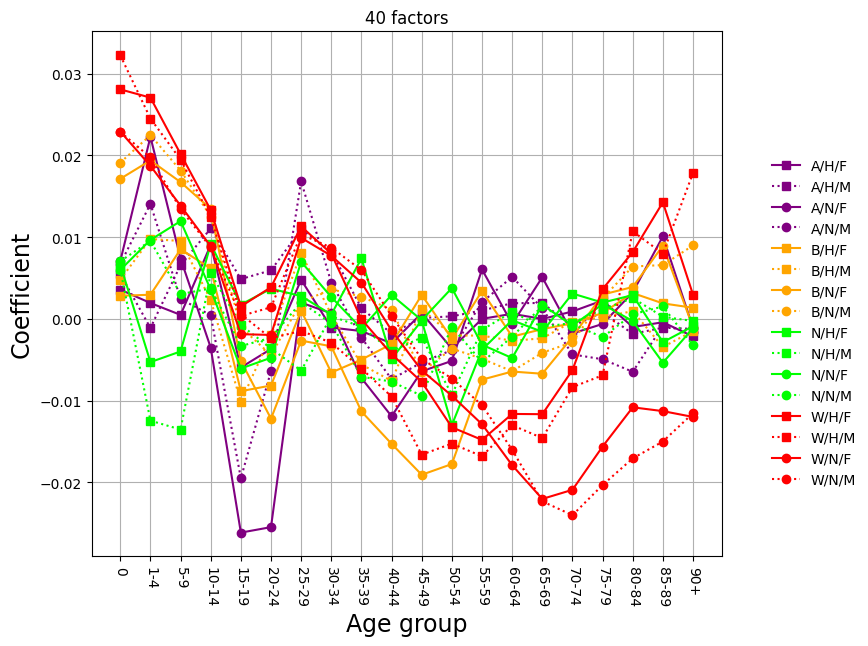

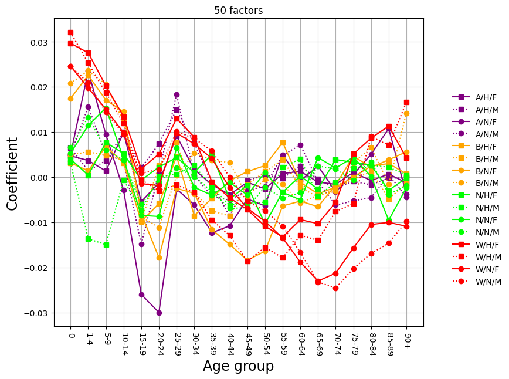

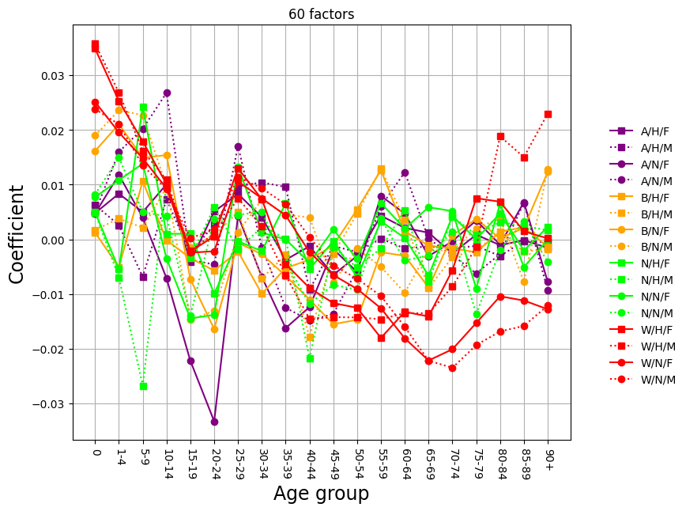

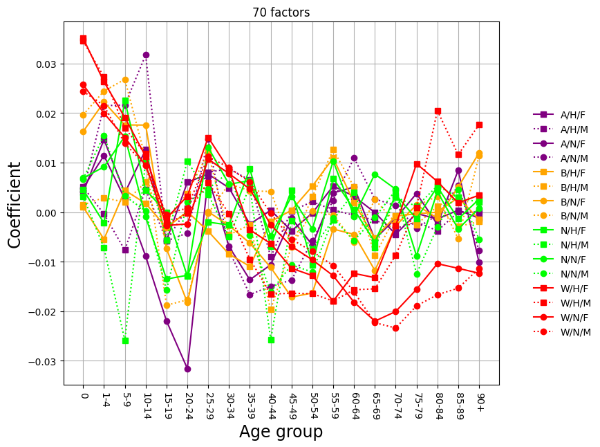

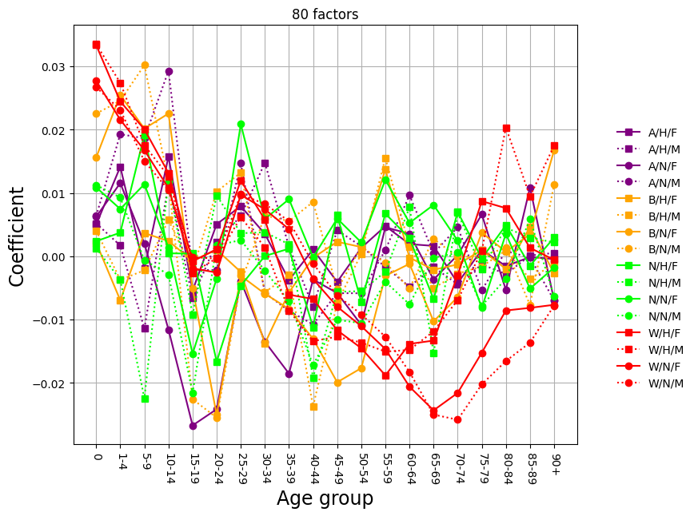

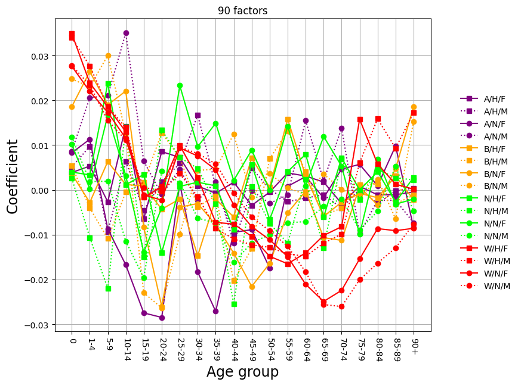

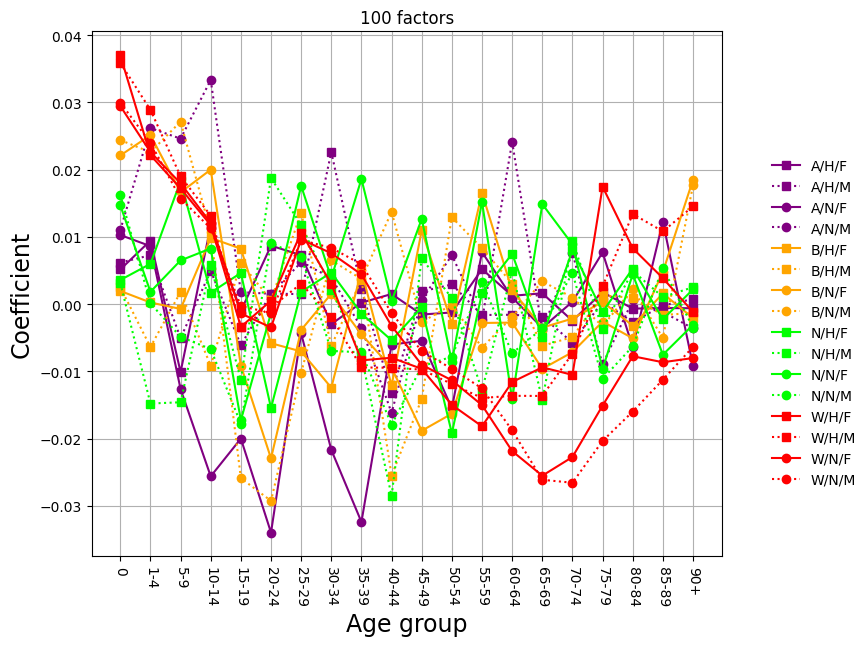

```python
models = []
for npc in pcs:

    c, m, r = fitmodel(npc)
    models.append((m, r))

    plt.clf()
    plt.figure(figsize=(9, 7))
    ax = plt.axes([0.14, 0.18, 0.7, 0.75])
    ax.grid(True)
    for i in range(c.shape[0]):
        a = c.index[i]
        la = "/".join(a)
        ax.plot(ages, c.iloc[i, :], lt[a[2]] + sym[a[1]], color=colors[a[0]],
                label=la)

    # Setup the horizontal axis labels
    ax.set_xticks(ages)
    ax.set_xticklabels(age_groups)
    for x in plt.gca().get_xticklabels():
        x.set_rotation(-90)

    ha, lb = plt.gca().get_legend_handles_labels()
    leg = plt.figlegend(ha, lb, loc="center right")
    leg.draw_frame(False)

    plt.xlabel("Age group", size=17)
    plt.ylabel("Coefficient", size=17)
    plt.title("%d factors" % npc)
    plt.show()
```

```python
for k in range(10):
    st = models[k+1][0].compare_score_test(models[k][1])
    print("%d versus %d: p=%f" % (pcs[k+1], pcs[k], st["p-value"]))
```

```
5 versus 0: p=0.000000
10 versus 5: p=0.000000
20 versus 10: p=0.000000
30 versus 20: p=0.000000
40 versus 30: p=0.000054
50 versus 40: p=0.043915
60 versus 50: p=0.000035
70 versus 60: p=0.414524
80 versus 70: p=0.032338
90 versus 80: p=0.354696
```